# Link Prediction lastFM

Emma Perez, Andrés Camargo

2023-05-03

Packages needed

```r
library(tidyverse)
library(igraph)
library(visNetwork)
library(ggplot2)
library(ggthemes)
library(caret)
library(stargazer)

set.seed(123)
```

## 0. Network description

*LastFM Asia Social Network*

The chosen network is a social network of LastFM Asian users available at the [Stanford Network Analysis Platform (SNAP)](https://snap.stanford.edu/index.html). Last.fm is a social media, an internet radio, and also a music recommendation system that builds profiles and statistics about musical preferences, based on data sent by registered users.

According to SNAP, the data was collected from the public API in March 2020. Nodes are LastFM users from Asian countries and edges are mutual follower relationships between them. The vertex features are extracted based on the artists liked by the users. It can be downloaded in csv format from [LastFM Asia Social Network](https://snap.stanford.edu/data/feather-lastfm-social.html).

The network will be used to perform link prediction, this is, to predict link formation between nodes in the real data.

To start with, the data is loaded to R. Then, it is converted into a graph object. Since edges are following relationships which are mutual between users, the network is undirected.

```r
fm = read_delim("lasftm_asia/lastfm_asia_edges.csv", delim=",")
g = graph.data.frame(fm, directed = FALSE)

g
```

```
## IGRAPH 41ebba8 UN-- 7624 27806 --
## + attr: name (v/c)
## + edges from 41ebba8 (vertex names):
##  [1] 0--747  1--4257 1--2194 1--580  1--6478 1--1222 1--5735 1--7146 1--2204
## [10] 1--126  1--2639 2--562  2--1492 2--6    2--5303 2--7128 2--4154 2--5179
## [19] 3--1728 3--4560 3--5060 3--1351 3--6503 3--7089 3--4319 3--6095 3--272
## [28] 3--4433 3--2900 3--3381 3--5943 3--2107 3--6940 3--2013 3--6046 3--5823
## [37] 4--5770 5--5454 6--5856 6--667  6--6180 6--598  6--870  6--3079 6--1834
## [46] 6--6283 6--7340 6--7279 6--342  6--1492 6--4405 6--1462 6--7128 6--1284
## [55] 6--1551 6--3291 6--167  7--177  7--6243 7--7589 7--2854 7--6931 7--6250
## [64] 7--428  7--2142 8--1686 9--4481 9--1795 9--2660 9--6053 9--246  9--3843
## + ... omitted several edges
```

Even it is quite big, we can try to visualize it in R.

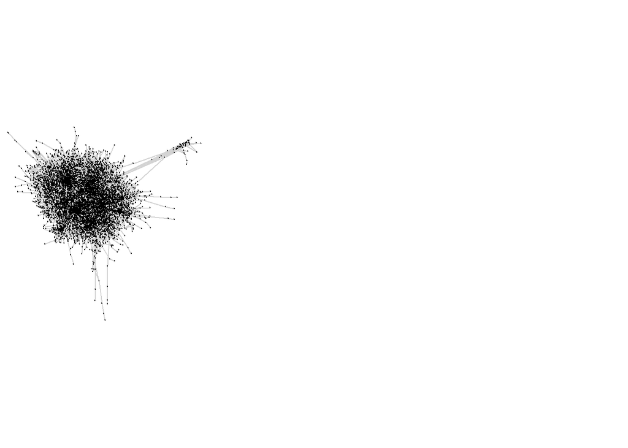

```r
par(mar=c(0,0,0,0),mfrow=c(1,3))
E(g)$color<-"lightgray"; V(g)$color <- "blue";ll <- layout.fruchterman.reingold.grid(g)

plot(g,layout=ll,vertex.label="", vertex.size = 1)
```

## 1. Edges deletion

*Delete a fraction of real edges in the network and create a table of those links deleted (positive class) and of links non-present (negative class)*

To perform the link inference, we first remove a fraction of links, so we get a new graph with fewer number of links (gp). Then, we will try to infer the deleted links with a binary classifier. To do so, we need two classes of links: a positive (those which are present) and a negative one (those links which do not exist)

```r
nlinks <- 1600 #links to be deleted (positive class)
ii <- sample(1:ecount(g),nlinks)
gp <- delete_edges(g,ii)
```

Table of deleted (true) links: we store the true deleted links in a separate table, which conforms the positive class.

```r
true_edges <- data.frame(get.edges(g,ii))
head(true_edges,6)
```

```
##     X1   X2
## 1 3122 5098
## 2 3134 3435
## 3 5198 5541
## 4 4618 4972
## 5  426 6053
## 6  257 3982
```

Table of false links: for links which are not actually there, we use false links between random nodes (the most connected ones) which are the negative class.

```r
false_edges <- data.frame()
most_connected <- which(degree(g)>10)
for(i in 1:nlinks){
  i1 <- sample(most_connected,1)
  i2 <- sample(most_connected,1)
  if(!are.connected(g,i1,i2)) false_edges <- rbind(false_edges,data.frame(X1=i1,X2=i2))
}

head(false_edges,6)
```

```
##        X1   X2
## 1705 1657 6448
## 2670 2563 5119
## 4069 3769 1590
## 3514 3303 2545
## 3705 3470 4160
## 6180 5241  217
```

Now that we have both kinds of links, we can put them together into a single table, adding an `obs` variable to distinguish them:

```r
true_edges <- data.frame(true_edges,obs=1)
false_edges <- data.frame(false_edges,obs=0)

# Joing all edges
total_edges <- rbind(true_edges,false_edges)
colnames(total_edges) <- c("id1","id2","obs")

head(total_edges,6)
```

```
##    id1  id2 obs
## 1 3122 5098   1
## 2 3134 3435   1
## 3 5198 5541   1
## 4 4618 4972   1
## 5  426 6053   1
## 6  257 3982   1
```

## 2. Similarity metrics

*Generate a number of proximity/similarty metrics heuristics for each link in the positive and negative class*

In the link prediction problem, the basic idea is that nodes which have large proximity are bound o have a link. Similarity metrics are measures of proximity in the social network by using the social structure of the graph. A key concept in these metrics is that of common neighbors: two nodes that share a lot of neighbors might be introduced by a common friend. With this idea we can construct different measures such as:

- Jaccard’s Coefficient: if nodes have very large connectivity, then they might probably share some neighbors. Thus we might consider instead the fraction of neighbors shared between them.
- Adamic-Adar: similar to number of common neighbors, but each neighbor is weighted inversely proportional to its degree (takes into account the degree of shared neighbors between two nodes). Thus nodes which have only as neighbors x and y count more than nodes with high connectivity that happen to have x and y as neighbors.
- Preferential attachment: mechanism in social networks where new connections are more likely to be formed between nodes that are already highly connected (rich get richer). If the probability that x and y get a new neighbor is proportional to their degree, the probability that a new link is formed between x and y grows with the product of their degrees.

Since we already have the table with all the nodes and links, we can compute the neighborhood of the nodes at each side of each link considered.

```r
n1 <- neighborhood(gp,order=1,nodes=total_edges$id1)
n2 <- neighborhood(gp,order=1,nodes=total_edges$id2)
```

As the neighborhoods are saved as lists, we can calculate the proximity metrics for each link in the following way:

```r
total_edges$sim_jacc <- 0
total_edges$sim_aa <- 0
total_edges$sim_pref <- 0

for(i in 1:nrow(total_edges)){
   common_neigh <- intersect(n1[[i]],n2[[i]])
   all_neigh <- union(n1[[i]],n2[[i]])
   degree_common_neigh <- degree(gp,common_neigh)
   total_edges$sim_jacc[i] <- length(common_neigh)/(length(all_neigh)-2)
   if(length(common_neigh)>0) total_edges$sim_aa[i] <- sum(1/log(degree_common_neigh))
   total_edges$sim_pref[i] <- length(n1[[i]])*length(n2[[i]])
}

head(total_edges)
```

```
##    id1  id2 obs  sim_jacc   sim_aa sim_pref
## 1 3122 5098   1 0.0000000 0.000000       20
## 2 3134 3435   1 0.0000000 0.000000       20
## 3 5198 5541   1 0.2941176 5.239811     2000
## 4 4618 4972   1 0.0000000 0.000000      155
## 5  426 6053   1 0.1136364 1.229717      540
## 6  257 3982   1 0.1142857 1.424023      378
```

To analyze the generated heuristics, we plot them in boxplots to see the differences between true and false links:

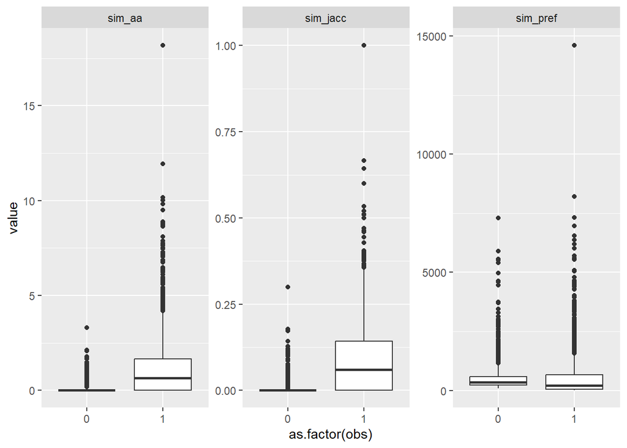

```r
total_edges %>% pivot_longer(c(sim_jacc,sim_aa,sim_pref)) %>%
  ggplot(aes(x=as.factor(obs),y=value)) + geom_boxplot() + facet_wrap(~name,scales="free")
```

## 3. Binary classifier training

*Train a binary classifier to predict the links, i.e., to predict the class (positive/negative) using those heuristics. Use crossvalidation.*

Now, we are ready to use the metrics as explanatory variables in a binary classifier which tries to predict real links (obs=1) and non-existent ones(obs=0). The classifier can take different forms, such as logistic regression or random forest.

To start with, the sample is divided into train and test.

```r
ii <- sample(1:nrow(total_edges),0.75*nrow(total_edges))
total_edges_train <- total_edges[ii,]
total_edges_test <- total_edges[-ii,]
```

To train the models with cross validation, we use the package caret. First, we fix the settings for the CV:

```r
# set the cv parameters
ctrl = trainControl(
  method = "repeatedcv",
  number = 10,
  classProbs = T,
  summaryFunction = twoClassSummary,
  verboseIter = T
  )
```

Second, we prepare the variables: put them as factor in both train and test samples and name their classes with postive (yes) and negative (no) labels.

```r
total_edges_train = total_edges_train %>% mutate(obs = as.factor(obs))
total_edges_test = total_edges_test %>% mutate(obs = as.factor(obs))
levels(total_edges_train$obs)= c("No","Yes")
levels(total_edges_test$obs)= c("No","Yes")
```

Now, we train the logistic model:

```r
logistic_cv = train(
  obs ~ sim_jacc+sim_aa+sim_pref,
  data = total_edges_train,
  method= "glm",
  family = "binomial",
  metric = "ROC",
  preProc= c('scale', 'center'),
  tuneLength= 10,
  trControl = ctrl)
#model summary
summary(logistic_cv$finalModel)
```

```
##
## Call:
## NULL
##
## Deviance Residuals:
##     Min       1Q   Median       3Q      Max
## -4.6509  -0.7606   0.0000   0.3960   5.7770
##
## Coefficients:
##             Estimate Std. Error z value Pr(>|z|)
## (Intercept)   1.6530     0.1463   11.30   <2e-16 ***
## sim_jacc      0.2701     0.2621    1.03    0.303
## sim_aa        6.4133     0.5218   12.29   <2e-16 ***
## sim_pref     -2.2477     0.1918  -11.72   <2e-16 ***
## ---
## Signif. codes:  0 '***' 0.001 '**' 0.01 '*' 0.05 '.' 0.1 ' ' 1
##
## (Dispersion parameter for binomial family taken to be 1)
##
##     Null deviance: 3310.2  on 2387  degrees of freedom
## Residual deviance: 1911.5  on 2384  degrees of freedom
## AIC: 1919.5
##
## Number of Fisher Scoring iterations: 8
```

It seems that the Jaccard’s coefficient is not statistically significant for the link prediction. We can check it also by looking at the variables importance:

We also train a random forest to compare the results and see which model has better performance:

```r
# train the rf model
rfFit = train(
  obs ~ sim_jacc+sim_aa+sim_pref,
  data = total_edges_train,
  method= "rf",
  preProc= c('scale', 'center'),
  tuneLength= 10,
  metric = "ROC",
  trControl = ctrl
)
```

## 4. Model evaluation

*Evaluate the precision of the model. Which heuristic is the most important. Why do you think it is the most important?*

Finally, we evaluate the performance of the models. To do so, we first compute the predictions produced by each one and fix a threshold that provides a good classification. Then, we compute the confusion matrix to check metrics such as general accuracy, sensitivity and specificity.

Additionally, we check which features are the most important ones.

#### 4.1 Evaluation of logistic model

```r
log_prediction <- predict(logistic_cv,total_edges_test,type="prob")
prediction = as.factor(ifelse(log_prediction[,2]>0.35, "Yes", "No"))

confusionMatrix(prediction, total_edges_test$obs)
```

```
## Confusion Matrix and Statistics
##
##           Reference
## Prediction  No Yes
##        No  361  31
##        Yes  42 363
##
##                Accuracy : 0.9084
##                  95% CI : (0.8862, 0.9275)
##     No Information Rate : 0.5056
##     P-Value [Acc > NIR] : <2e-16
##
##                   Kappa : 0.8168
##
##  Mcnemar's Test P-Value : 0.2418
##
##             Sensitivity : 0.8958
##             Specificity : 0.9213
##          Pos Pred Value : 0.9209
##          Neg Pred Value : 0.8963
##              Prevalence : 0.5056
##          Detection Rate : 0.4529
##    Detection Prevalence : 0.4918
##       Balanced Accuracy : 0.9086
##
##        'Positive' Class : No
##
```

Which heuristic is the most important?

```r
varImp(logistic_cv, scale = FALSE)
```

```
## glm variable importance
##
##          Overall
## sim_aa     12.29
## sim_pref   11.72
## sim_jacc    1.03
```

The most important similarity measure in this model is the Adamic-Adar one, followed closely by preferential attachment.

#### 4.2 Evaluation of random forest model

```r
rfProb = predict(rfFit, total_edges_test, type = "prob")
prediction = as.factor(ifelse(rfProb[,2]>0.1, "Yes", "No"))

confusionMatrix(prediction, total_edges_test$obs)
```

```
## Confusion Matrix and Statistics
##
##           Reference
## Prediction  No Yes
##        No  338  19
##        Yes  65 375
##
##                Accuracy : 0.8946
##                  95% CI : (0.8712, 0.9151)
##     No Information Rate : 0.5056
##     P-Value [Acc > NIR] : < 2.2e-16
##
##                   Kappa : 0.7895
##
##  Mcnemar's Test P-Value : 9.112e-07
##
##             Sensitivity : 0.8387
##             Specificity : 0.9518
##          Pos Pred Value : 0.9468
##          Neg Pred Value : 0.8523
##              Prevalence : 0.5056
##          Detection Rate : 0.4241
##    Detection Prevalence : 0.4479
##       Balanced Accuracy : 0.8952
##
##        'Positive' Class : No
##
```

To see variable importance in this case:

```r
varImp(rfFit, scale = FALSE)
```

```
## rf variable importance
##
##          Overall
## sim_pref   502.8
## sim_aa     446.2
## sim_jacc   164.2
```

For the random forest method, the most important variable is the preferential attachment metric, followed by Adamic-Adar and Jaccard’s coefficient.

For the two models, the most important heuristics are Adamic-Adar and preferential attachment. Why could this be?

It’s possible that the Adamic-Adar similarity measure captures important structural information about the network that other features do not. For example, if the LastFM network has a structure where a few highly connected nodes are surrounded by many less connected nodes, the Adamic-Adar measure may be particularly effective at capturing the importance of the highly connected nodes.We already saw in the boxplots of heuristics that the Adamic-Adar metric was the one in which there is a bigger difference between real and false links. Probably, the models are capturing this and using it to distinguish between the two.

Additionally, preferential attachment is related to the distribution of node degrees in the network. Since our network has a few highly connected nodes (hubs, as we saw in the degree distribution of the LastFM network in homework 1) and many less connected nodes, preferential attachment is capturing the importance of the highly connected nodes. Since both models show a high performance, probably the structure of LastFM network is according to this explanation.

## 5. Potential improvements

*Comment on potential ways to improve the link prediction*

To improve our models for link prediction, we can include more significant variables.

Firstly, we can incorporate additional metrics that relate to community structure, as we observed in our previous analysis that this network has a modularity higher than 80%. Adding this metric may improve the performance of our model.

Secondly, we can also consider utilizing PageRank scores to predict links between nodes in the network. Since nodes with high PageRank scores are likely to be linked to other important nodes, this could provide valuable information for our model.

Thirdly, computing the shortest path distances between all pairs of nodes could be beneficial. This involves identifying the path with the minimum number of links between each pair of nodes in the network. We could then use this information to identify pairs of nodes with short distances between them, indicating that they are likely to be connected in the future.

Fourthly, other proximity metrics, such as the Katz score, could provide useful insights. This score measures interconnections between nodes and could be used as input for link prediction.

Finally, the Hyper-link induced topic search (HITS) is another feature that our model could evaluate. HITS assigns an Authority score (based on incoming links) and Hub score (based on outgoing links) to each node, and can explain changes in the network over time.